# Stat 480 - Homework #1

Jeremy Miranda

1/23/2018

### Importing data sets

```r
life5060 <- read.csv("https://raw.githubusercontent.com/Stat480-at-ISU/materials/master/01_collaborative-environment/data/gapminder-5060.csv")

life7080 <- read.csv("https://stat480-at-isu.github.io/homework/data/gap7080.csv")
head(life7080)
```

```
##       country continent year lifeExp      pop gdpPercap
## 1 Afghanistan      Asia 1972  36.088 13079460  739.9811
## 2 Afghanistan      Asia 1977  38.438 14880372  786.1134
## 3 Afghanistan      Asia 1982  39.854 12881816  978.0114
## 4 Afghanistan      Asia 1987  40.822 13867957  852.3959
## 5     Albania    Europe 1972  67.690  2263554 3313.4222
## 6     Albania    Europe 1977  68.930  2509048 3533.0039
```

### Combined data

```r
combined <- rbind(life5060, life7080)
```

### Filter Canada

```r
canada <- combined %>% filter(country == "Canada")
head(canada)
```

```
##   country continent year   lifeExp      pop gdpPercap
## 1  Canada  Americas 1952     68.75 14785584  11367.16
## 2  Canada  Americas 1957 999999.00 17010154  12489.95
## 3  Canada  Americas 1962     71.30 18985849  13462.49
## 4  Canada  Americas 1967     72.13 20819767  16076.59
## 5  Canada  Americas 1972     72.88 22284500  18970.57
## 6  Canada  Americas 1977     74.21 23796400  22090.88
```

### Canada graph

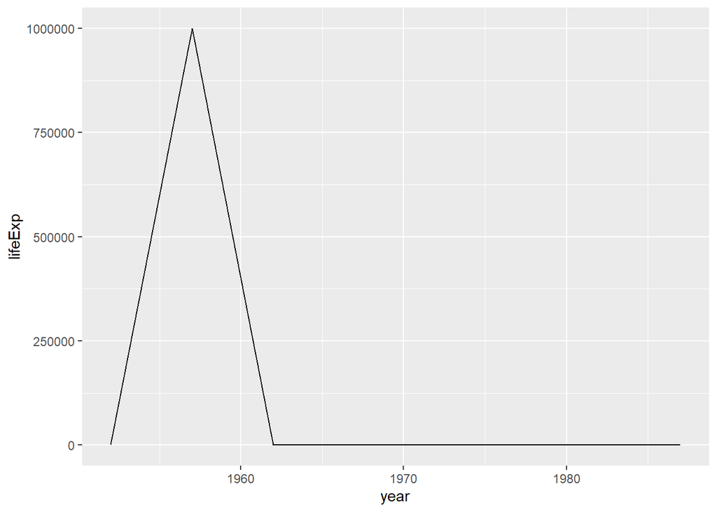

```r
canada %>%
  ggplot(aes(x = year, y = lifeExp)) +
  geom_line()
```

### Fix Canada data

```r
canada %>% filter(year == 1957)
```

```
##   country continent year lifeExp      pop gdpPercap
## 1  Canada  Americas 1957  999999 17010154  12489.95
```

```r
canada_fixed <- canada %>% mutate(lifeExp = replace(lifeExp, year==1957, 69.96))
```

### Graph of fixed Canada data

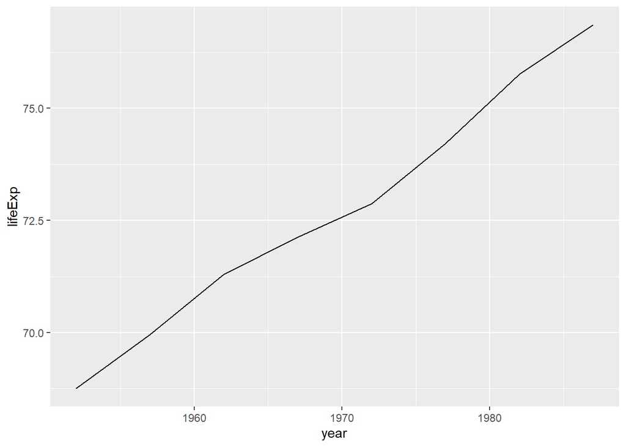

```r
canada_fixed %>% ggplot(aes(x = year, y = lifeExp)) +
  geom_line()
```

### Graph of US, Mexico, and Canada using combined data

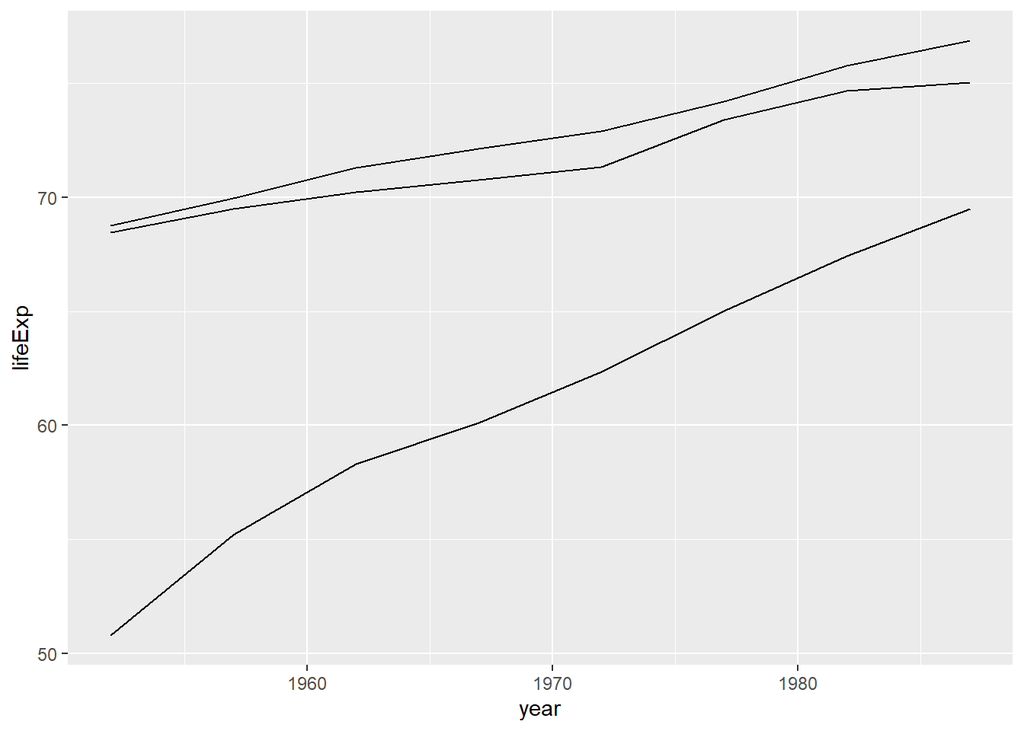

```r
canada_fixed %>%
  ggplot(aes(x = year, y = lifeExp, group=country)) + geom_line() +
  geom_line(data = combined %>%
              filter(country %in% c("United States", "Mexico")))
```

### Graph of US, Mexico, and Canada using combined data with color

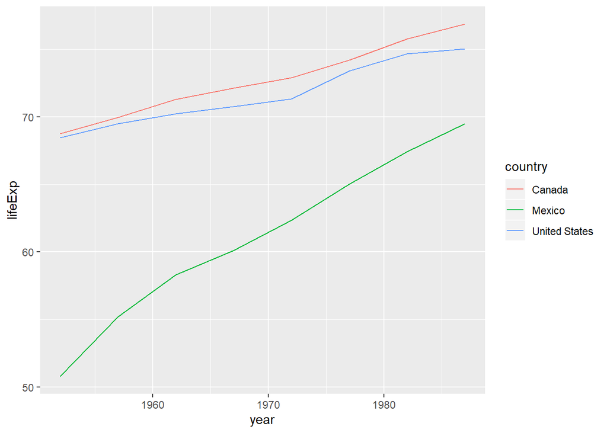

```r
canada_fixed %>%
  ggplot(aes(x = year, y = lifeExp, colour=country)) + geom_line() +
  geom_line(data = combined%>%
              filter(country %in% c("United States", "Mexico")))
```

### Write Up

I noticed that Mexicos life expectancy is extremely low compared to the US and Canada. Even though Mexico’s life expectancty has steadily increased it’s still a substantial distance away from the US and Canada. What stuck out the most to me is how large the gap in life expectancy is from 1950 to 1970 when you compare Mexico to the US and Canada. I do wonder why the US and Canada are so close when it comes to life expectancy. I can think of a couple reasons (i.e. health care and obesity rates) but it would be interesting to do more research to see if there is one reason inparticular the two countries are so close.

## Life Expectancy 1950 - 1990

1. Download the RMarkdown file with these homework instructions to use as a template for your work. Make sure to replace “Your Name” in the YAML with your name.
2. In class, we have discussed life expectancy in Canada, Mexico and the United States in the 50s and 60s. Additional data for the 70s and 80s is available in the file gap7080.csv. Use the R Markdown file with the sample solution for the test case (see the online schedule for a link) to extend our class solution and include values for the 70s and 80s, i.e. you are asked to
   1. Visualize the life expectancy for the United States, Canada and Mexico in a line chart (with three lines in different colours).
   2. Comment in your writeup about what you see in the plot. Make sure that the incorrect value for Canada in 1957 is fixed.

Note:

1. this homework is supposed to be mainly a code reading exercise. You should not have to program extensively. Instead, you have to figure out which pieces you need to copy and adjust.
2. the R command for combining two datasets that have the same structure is `rbind`, used as:

```
combined <- rbind(data1, data2)
```

For the submission: submit your solution in an R Markdown file and (just for insurance) submit the corresponding html file with it.